# 지도학습 알고리즘

## 1. ROC & AUC

### 1.1 ROC 커브

- ROC 커브 아래의 면적 AUC를 사용하여 모델 간의 비교를 한다.
- AUC 가 클수록 좋은 모델이다.

## 2. 서포트 벡터 머신(Support Vector Machine)

- 두 개 이상으로 나뉜 집단을 분류할 때 사용하는 머신러닝 기법이다.
- 분류 알고리즘 중 가장 정확도가 높은 것 중 하나이다.
- 다양한 분류 상황에서 좋은 성능을 보이고, 이상치 영향도 적게 받는 것으로 알려져 있다.

### 2.1 초평면

- 데이터와 경계 사이의 거리를 마진(margin), 이 마진(margin)에서 가장 가까운 데이터를 support vector 라고 한다.
- support vector 와 margin 을 이용하여 그린 선이 최적의 경계가 되고, 이를 초평면이라 한다.

### 2.2 SVM 연습

#### 2.2.1 데이터 불러오기

```r
autoparts <- read.csv("autoparts.csv",header=T)
autoparts1 <- autoparts[autoparts$prod_no=="90784-76001",c(2:11)]
autoparts2 <- autoparts1[autoparts1$c_thickness<1000,]

autoparts2$y_faulty <- ifelse(  (autoparts2$c_thickness<20)|(autoparts2$c_thickness>32),1,0  )
head(autoparts2)
```

```
##   fix_time a_speed b_speed separation s_separation rate_terms  mpa
## 1     85.5   0.611   1.715      242.0        657.6         95 78.2
## 2     86.2   0.606   1.708      244.7        657.1         95 77.9
## 3     86.0   0.609   1.715      242.7        657.5         95 78.0
## 4     86.1   0.610   1.718      241.9        657.3         95 78.2
## 5     86.1   0.603   1.704      242.5        657.3         95 77.9
## 6     86.3   0.606   1.707      244.5        656.9         95 77.9
##   load_time highpressure_time c_thickness y_faulty
## 1      18.1                58        24.7        0
## 2      18.2                58        22.5        0
## 3      18.1                82        24.1        0
## 4      18.1                74        25.1        0
## 5      18.2                56        24.5        0
## 6      18.0                78        22.9        0
```

#### 2.2.2 데이터셋 나누기

```r
t_index <- sample(1:nrow(autoparts2), size=nrow(autoparts2) *0.7)
train <- autoparts2[t_index, ] # 훈련데이터(70%)
test <- autoparts2[-t_index, ] # 검증데이터(30%)
nrow(train); nrow(test);
```

```
## [1] 15236
```

```
## [1] 6531
```

#### 2.2.3 파라미터 최적값 찾기

```r
#install.packages("e1071")
library(e1071)
# gamma와 cost 의 최적의 값을 찾기.
#tune.svm(factor(y_faulty)~fix_time+a_speed+b_speed+separation+s_separation+rate_terms+mpa+load_time+highpressure_time,
#         data=autoparts2, gamma=2^(-1:1), cost=2^(2:4))

#gamma는 초평면의 기울기이고, cost는 과적합에 따른 비용이다. 과적합될수록 cost가 상승한다. 즉, 어느 정도의 비용을
#감수하더라도 모델을 훈련데이터에 맞추겠는지이다.
# 가장 좋은 결과를 산출하는 파라미터를 찾는다.
```

#### 2.2.4 모델 생성 1

```r
m <- svm(factor(y_faulty)~fix_time+a_speed+b_speed+separation+s_separation+rate_terms+mpa+load_time+highpressure_time,
                  data=train, gamma=2, cost=16)

summary(m)
```

```
##
## Call:
## svm(formula = factor(y_faulty) ~ fix_time + a_speed + b_speed +
##     separation + s_separation + rate_terms + mpa + load_time +
##     highpressure_time, data = train, gamma = 2, cost = 16)
##
##
## Parameters:
##    SVM-Type:  C-classification
##  SVM-Kernel:  radial
##        cost:  16
##       gamma:  2
##
## Number of Support Vectors:  2222
##
##  ( 1027 1195 )
##
##
## Number of Classes:  2
##
## Levels:
##  0 1
```

#### 2.2.5 검증데이터로 예측값 및 정확도 구하기

```r
yhat_test <- predict(m, test)
table <- table(real=test$y_faulty, predict=yhat_test)
((table[1,1] + table[2,2]) / sum(table)) #정분류율.
```

```
## [1] 0.9615679
```

```r
table[2,2]/sum(table[2,]) # 민감도(재현도 , 소수집단 정분류율): 실제 값들 중에 소수집단을 정분류한 것.
```

```
## [1] 0.8476978
```

#### 2.2.6 모델 생성 2: linear kernel

```r
m <- svm(factor(y_faulty)~fix_time+a_speed+b_speed+separation+s_separation+rate_terms+mpa+load_time+highpressure_time,
         data=train, gamma=2, cost=16, kernel="linear")

yhat_test <- predict(m, test)
table <- table(real=test$y_faulty, predict=yhat_test)
(table[1,1]+table[2,2])/sum(table) # 기본값인 radial 의 경우보다 예측률이 떨어진 것을 알 수 있다.
```

```
## [1] 0.9148676
```

#### 2.2.7 모델 생성 3: 기본 커널, 기본 파라미터

```r
m <- svm(factor(y_faulty)~fix_time+a_speed+b_speed+separation+s_separation+rate_terms+mpa+load_time+highpressure_time,
         data=train)

yhat_test <- predict(m, test)
table <- table(real=test$y_faulty, predict=yhat_test); table
```

```
##     predict
## real    0    1
##    0 5609   75
##    1  476  371
```

```r
(table[1,1]+table[2,2])/sum(table)
```

```
## [1] 0.9156331
```

#### 2.2.8 ROC, AUC

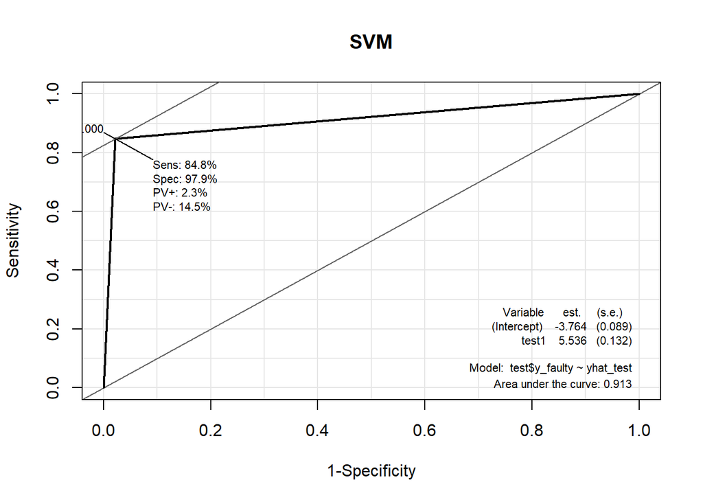

```r
m <- svm(factor(y_faulty)~fix_time+a_speed+b_speed+separation+s_separation+rate_terms+mpa+load_time+highpressure_time,
         data=train, gamma=2, cost=16)

yhat_test <- predict(m, test)

#install.packages("Epi")
library(Epi)
ROC(test=yhat_test, stat=test$y_faulty, plot='ROC', AUC=T, main="SVM")
```

#### 2.2.9 새로운 데이터 예측

- 한개 데이터 예측

```r
new.data <- data.frame(fix_time=87, a_speed=0.609, b_speed=1.715, separation=242.7, s_separation=657.5,
                       rate_terms=95, mpa=78, load_time=18.1, highpressure_time=82)

predict(m, newdata = new.data) # 0(정상) 으로 분류되었다.
```

```
## 1
## 0
## Levels: 0 1
```

- 복수 데이터 예측 1

```r
new.data <- data.frame(fix_time=c(87,85.6), a_speed=c(0.609,0.472), b_speed=c(1.715,1.685), separation=c(242.7,243.4), s_separation=c(657.5,657.9),
                       rate_terms=c(95,95), mpa=c(78,28.8), load_time=c(18.1,18.2), highpressure_time=c(82,60))

predict(m, newdata = new.data) # 1번은 0(정상), 2번은 1(불량) 으로 분류되었다.
```

```
## 1 2
## 0 1
## Levels: 0 1
```

- 복수 데이터 예측 2

```r
new.data <- data.frame(fix_time=test$fix_time, a_speed=test$a_speed, b_speed=test$b_speed,
                       separation=test$separation, s_separation=test$s_separation, rate_terms=test$rate_terms,
                       mpa=test$mpa, load_time=test$load_time, highpressure_time=test$highpressure_time)

head(p <- predict(m, newdata = new.data))
```

```
## 1 2 3 4 5 6
## 0 0 1 1 1 1
## Levels: 0 1
```

```r
summary(p)
```

```
##    0    1
## 5691  840
```

- cost가 높을수록 이상치를 포함할확률이 높아져서 과대적합의 가능성도 높아짐.
- r(감마)가 커질수록 개체간 분산이 작아지(개체간 영향력이 커짐)고 곡선률(옆 개체에 미치는 영향력)이 커져 과대적합 가능성이 높아짐.

### 2.3 서포트 벡터 회귀(Support Vector Regression)

- 종속변수 연속형인 경우도 가능.
- 서로 다른 분류에 속한 `관측치 사이에 간격이 최대가 되는 선` 으로 연결한 것으로 바이너리한 값이 아니라 연속된 수치로 예측이 가능하다.

```r
autoparts <- read.csv("autoparts.csv",header=T)
autoparts1 <- autoparts[autoparts$prod_no=="90784-76001",c(2:11)]
autoparts2 <- autoparts1[autoparts1$c_thickness<1000,]
autoparts2$y_faulty <- ifelse((autoparts2$c_thickness<20)|(autoparts2$c_thickness>32),1,0)

t_index <- sample(1:nrow(autoparts2), size=nrow(autoparts2) *0.7)
train <- autoparts2[t_index, ] # 훈련데이터(70%)
test <- autoparts2[-t_index, ] # 검증데이터(30%)
nrow(train); nrow(test);
```

```
## [1] 15236
```

```
## [1] 6531
```

#### 2.3.1 서포트 벡터 회귀 모델 생성

```r
m <- svm(c_thickness~fix_time+a_speed+b_speed+separation+s_separation+rate_terms+mpa+load_time+highpressure_time,
         data=train, gamma=2, cost=16)
summary(m)
```

```
##
## Call:
## svm(formula = c_thickness ~ fix_time + a_speed + b_speed + separation +
##     s_separation + rate_terms + mpa + load_time + highpressure_time,
##     data = train, gamma = 2, cost = 16)
##
##
## Parameters:
##    SVM-Type:  eps-regression
##  SVM-Kernel:  radial
##        cost:  16
##       gamma:  2
##     epsilon:  0.1
##
##
## Number of Support Vectors:  2840
```

#### 2.3.2 그래프 확인

- 연속형 이므로 정확도가 아닌 mse 값으로 비교한다.

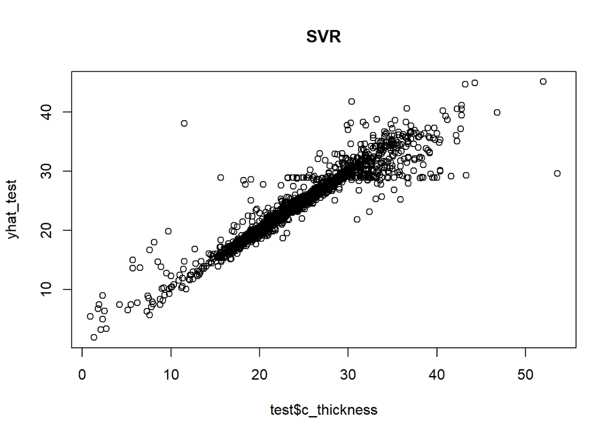

```r
yhat_test <- predict(m, test)
plot(x = test$c_thickness, y=yhat_test, main="SVR")
```

```r
mse <- mean((yhat_test - test$c_thickness)^2);
mse
```

```
## [1] 1.320308
```

#### 2.3.3 다중선형 회귀모형과의 비교

```r
m2 <- lm(c_thickness~fix_time+a_speed+b_speed+separation+s_separation+rate_terms+mpa+load_time+highpressure_time,
         data=train)
summary(m2)
```

```
##
## Call:
## lm(formula = c_thickness ~ fix_time + a_speed + b_speed + separation +
##     s_separation + rate_terms + mpa + load_time + highpressure_time,
##     data = train)
##
## Residuals:
##      Min       1Q   Median       3Q      Max
## -24.5263  -0.6087  -0.0163   0.5601  29.3212
##
## Coefficients:
##                     Estimate Std. Error  t value Pr(>|t|)
## (Intercept)        7.127e+02  4.082e+00  174.594  < 2e-16 ***
## fix_time           7.190e-02  6.914e-03   10.399  < 2e-16 ***
## a_speed           -1.663e+01  5.100e-01  -32.600  < 2e-16 ***
## b_speed            1.886e+00  1.811e-01   10.415  < 2e-16 ***
## separation        -7.581e-01  4.400e-03 -172.281  < 2e-16 ***
## s_separation      -7.458e-01  4.449e-03 -167.653  < 2e-16 ***
## rate_terms         1.291e-02  4.342e-03    2.974  0.00294 **
## mpa               -1.524e-01  1.758e-03  -86.672  < 2e-16 ***
## load_time         -1.752e-01  1.048e-02  -16.716  < 2e-16 ***
## highpressure_time -1.219e-05  9.345e-06   -1.305  0.19196
## ---
## Signif. codes:  0 '***' 0.001 '**' 0.01 '*' 0.05 '.' 0.1 ' ' 1
##
## Residual standard error: 1.815 on 15226 degrees of freedom
## Multiple R-squared:  0.778,  Adjusted R-squared:  0.7779
## F-statistic:  5930 on 9 and 15226 DF,  p-value: < 2.2e-16
```

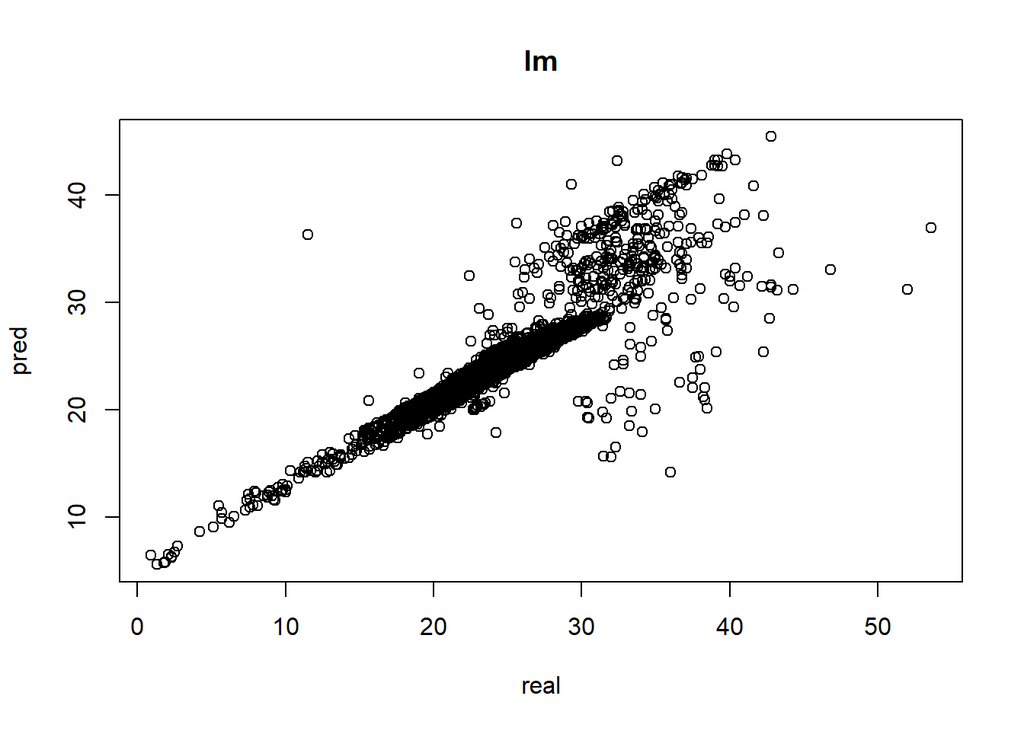

```r
# Adjusted R-squared 는 독립변수가 많아질수록 값이 커지는 현상을 방지.

yhat_test <- predict(m2, test)
plot(x=test$c_thickness, y=yhat_test, main="lm",xlab="real",ylab="pred")
```

```r
mse <- mean((yhat_test - test$c_thickness)^2)
mse
```

```
## [1] 3.074969
```

`비교` - SVR은 그래프의 끝 쪽에서는 예측력이 떨어지는 경향이 있다. - 다중회귀모형과 SVR 의 모델은 모든 데이터 셋마다 비교를 해줘야 한다.

### 2.4 단순 선형 회귀모형과의 비교

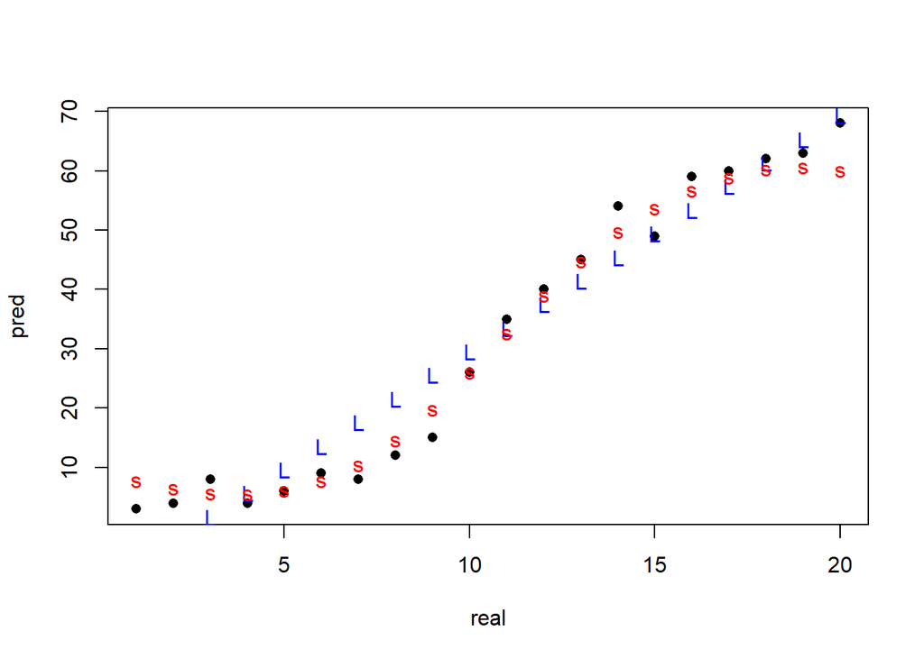

```r
regression <- read.csv("regression.csv",header=T)
plot(regression$x, regression$y, pch=16, xlab="real",ylab="pred")

#LM
m1 <- lm(y~x, data=regression)
p1 <- predict(m1, newdata=regression)
points(regression$x, p1, col='blue',pch='L')

#SVR

m2<- svm(y~x, data=regression)
p2 <- predict(m2, newdata=as.matrix(regression))
points(regression$x, p2, col='red', pch='s')
```

`SVR은 그래프의 끝쪽에서 오차가 커지는 것을 볼 수 있다.`

### example

#### 연습 1)

```r
# 1개의 임의의 데이터를 예측하시오.
predict(m2, newdata = data.frame(x=5))
```

```
##        1
## 6.066055
```

#### 연습 2)

```r
# 2개의 임의의 데이터를 예측하시오.
predict(m2, newdata = data.frame(x=c(5,12)))
```

```
##         1         2
##  6.066055 38.941073
```

## 3. 이항 로지스틱 회귀분석

### 3.1 이항 로지스틱 회귀모형

- 목표 변수가 이분형이거나 범주형인 경우, 로지스틱 회귀분석 수행

### 3.2 Odds Ratio 계산

### 3.3 실습

#### 3.3.1.데이터 준비

```r
autoparts <- read.csv("autoparts.csv",header=T)
autoparts1 <- autoparts[autoparts$prod_no=="90784-76001",c(2:11)]
autoparts2 <- autoparts1[autoparts1$c_thickness<1000,]
autoparts2$y_faulty <- ifelse((autoparts2$c_thickness<20)|(autoparts2$c_thickness>32),1,0)
```

#### 3.3.2.종속변수를 팩터로 만들기

```r
autoparts2$y_faulty <- as.factor(autoparts2$y_faulty)
```

#### 3.3.3 로지스틱 회귀모형 모델 생성

```r
m <- glm(y_faulty ~ fix_time + a_speed + b_speed + separation + s_separation + rate_terms + mpa + load_time +
           highpressure_time, data=autoparts2, family=binomial(logit))

# 계수가 양수인 것은 해당 변수가 1 증가할 때마다 y_faulty가 계수 배만큼 증가한다는 의미이다. 음수는 반대.
```

#### 3.3.4 데이터셋 나누기

```r
t_index <- sample(1:nrow(autoparts2), size=nrow(autoparts2)*0.7)
train <- autoparts2[t_index,]
test <- autoparts2[-t_index,]
```

#### 3.3.5 훈련데이터로 모델 만들기

```r
m <- glm(y_faulty ~ fix_time + a_speed + b_speed + separation + s_separation + rate_terms + mpa + load_time +
           highpressure_time, data=train, family=binomial(logit))
head(m$fitted.values) # 결과 값이 1일 확률.
```

```
##        8613       17766       21796        1590       24378       23826
## 0.033765551 0.015251438 0.004271353 0.003959880 0.008852844 0.017433462
```

#### 3.3.6 기준값 설정하기

```r
yhat <- ifelse(m$fitted.values>=0.5, 1,0)
```

#### 3.3.7 빈도표 작성하기

```r
table <- table(real=train$y_faulty, predict=yhat)
table
```

```
##     predict
## real     0     1
##    0 13021   231
##    1  1132   852
```

#### 3.3.8 예측값 구하기

```r
yhat_test <- predict(m, test, type="response")
```

#### 3.3.9 ROC, AUC

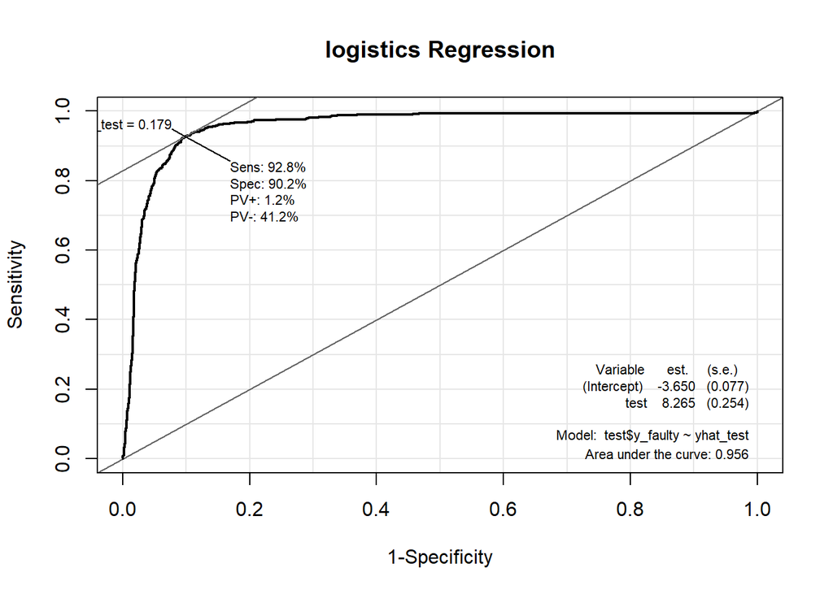

```r
library(Epi)
ROC(test=yhat_test, stat=test$y_faulty, plot = "ROC",AUC=T, main="logistics Regression")
```

### 3.4 새로운 데이터 예측

#### 3.4.1 1개 데이터 예측

```r
new.data <- data.frame(fix_time=87, a_speed=0.609, b_speed=1.715, separation=242.7, s_separation=657.5,
                       rate_terms=95, mpa=78, load_time=18.1, highpressure_time=82)
possibilityOf1<- predict(m, newdata = new.data, type="response")
ifelse(possibilityOf1>=0.5 ,1,0) # 벡터의 첫번째 요소에서 '0' (정상)이라는 판결이 나옸다.
```

```
## 1
## 0
```

#### 3.4.2 복수 데이터1 예측(벡터)

```r
new.data <- data.frame(fix_time=c(87,85.6), a_speed=c(0.609,0.472), b_speed=c(1.715,1.685),separation=c(242.7,243.4), s_separation=c(657.5,657.9),
                       rate_terms=c(95,95), mpa=c(78,28.8), load_time=c(18.1,18.2), highpressure_time=c(82,60))

possibilityOf1 <- predict(m, newdata=new.data, type="response")
ifelse(possibilityOf1>=0.5 ,1,0)
```

```
## 1 2
## 0 1
```

#### 3.4.1 복수 데이터2 예측(데이터 프레임)

```r
new.data <- data.frame(fix_time=test$fix_time, a_speed=test$a_speed, b_speed=test$b_speed,
                       separation=test$separation, s_separation=test$s_separation, rate_terms=test$rate_terms,
                       mpa=test$mpa, load_time=test$load_time, highpressure_time=test$highpressure_time)

possibilityOf1 <- predict(m, newdata=new.data, type="response")
classify <- ifelse(possibilityOf1>=0.5, 1, 0)
```

## 4. 다항 로지스틱 모형

### 4.1 다항 로지스틱 모형 구현

- 종속변수가 둘 이상일 때는 분포가정을 이항분포가 아니라 다항분포로 가정해야 한다.

### 4.2 실습

#### 4.2.1 다항 종속변수 생성

```r
autoparts2$g_class <- as.factor(ifelse(autoparts2$c_thickness<20,1, ifelse(autoparts2$c_thickness>32,2,3)  ))
table(autoparts2$g_class)
```

```
##
##     1     2     3
##  2141   701 18925
```

#### 4.2.2 훈련데이터와 검증데이터 만들기

```r
t_index <- sample(1:nrow(autoparts2), nrow(autoparts2)*0.7 )
train <- autoparts2[t_index,]
test <- autoparts2[-t_index,]
```

#### 4.2.3 훈련데이터로 모델 만들기

```r
library(nnet)
m <- multinom(g_class ~ fix_time,+a_speed+b_speed+separation+s_separation+rate_terms+mpa+load_time+highpressure_time,data = train )
```

#### 4.2.4 모델의 계수 정보 확인

```r
summary(m)
```

```
## Call:
## multinom(formula = g_class ~ fix_time, data = train, weights = +a_speed +
##     b_speed + separation + s_separation + rate_terms + mpa +
##     load_time + highpressure_time)
##
## Coefficients:
##   (Intercept)    fix_time
## 2   -2.218017  0.01639361
## 3   15.482555 -0.15873347
##
## Std. Errors:
##   (Intercept)     fix_time
## 2  0.02276044 0.0002674806
## 3  0.02045837 0.0002431193
##
## Residual Deviance: 16530127
## AIC: 16530135
```

#### 4.2.5 훈련데이터에 적합시킨 결과 확인하기

```r
head(m$fitted.values) # 각 범주에 분류될 확률을 나타내줌.
```

```
##                1          2         3
## 16507 0.06293851 0.02571580 0.9113457
## 25636 0.06477777 0.02655422 0.9086680
## 24336 0.06666485 0.02741753 0.9059176
## 3380  0.10976688 0.04788875 0.8423444
## 931   0.13341958 0.05965698 0.8069234
## 22143 0.06860063 0.02830632 0.9030931
```

#### 4.2.6 검증데이터로 예측값 및 정확도 구하기

```r
yhat_test <- predict(m, test)
table <- table(real=test$g_class, predict=yhat_test)
table
```

```
##     predict
## real    1    2    3
##    1    0    0  674
##    2   15    0  190
##    3   13    0 5639
```

```r
(table[1,1] + table[2,2] + table[3,3])/ sum(table) #정분류율
```

```
## [1] 0.8634206
```